# Jackknife creation

Michel Mariën

28 november 2018

# Introduction

This presentation was made to fulfil the final assignment of course 9 of the Data Science Specialization on Coursera

This assignment has two parts.

- Create a Shiny application and deploy online.
- Create a reproducible pitch presentation and deploy online.

# Functionality

The application allows the user to prioritise maintenance activities by making a jackknife diagram based on the downtime per failure and the number of failures per component. The components with the highest priorities are displayed in shades of red

The user can upload his own data in .csv-format using the downloadable uploadsheet. Furthermore, it is possible to set an upper and lower limit on the time interval thus excluding datapoints based on failure date.

Finally it is also possible to look at an historic trend of the components by splitting the dataset in calender time intervals.

# Source code

Source code for ui.R and server.R is avaliable at:

https://github.com/Vosmeer/Course9Week4

Application is running at:

https://mainformatics.shinyapps.io/jackknife_01/

# Source code

Below is an example Jackknife plot, created with the “Data_Jackknife_1.csv” dataset, located at https://github.com/Vosmeer/Course9Week4

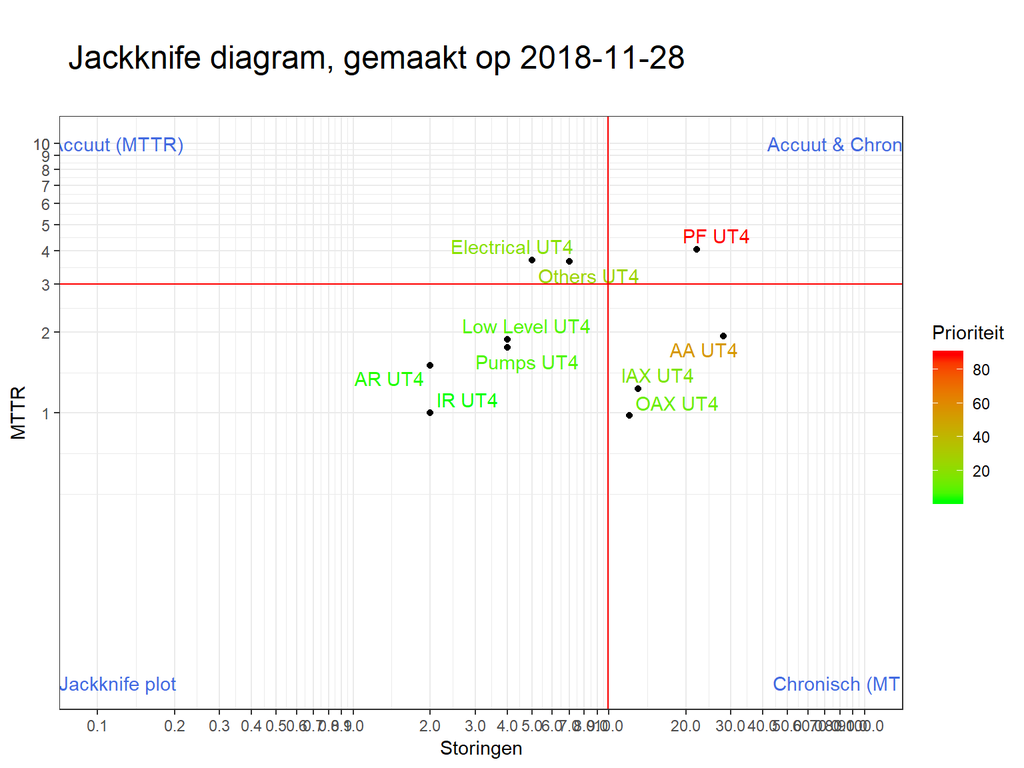

# The Application

The application is generating a scatterplot, based on mean downtime and the number of failures.

To use the application, the user should do the following:

1. Upload data set, using the downloadable uploadsheet (alternatively, use example data in repository)
2. Select the correct column separator (“Kolom scheidingsteken”)
3. Choose the date interval with the inputboxes “Begindatum” (startdate) and Einddatum (enddate)
4. Select the trend interval on which the data has to be grouped in the section “Trendinterval”. The possibilities are:
   - None (“Compleet”)
   - Year (“Jaar”)
   - Quarter (“Kwartaal”)
   - Month (“Maand”)
   - Week (“Week”)
5. Check the resulting data summary in the tab “Samenvatting”
6. Check the resulting Jackknife plot in the tab “Jackknife”
7. After the Jackknife plot is configured, it can be downloaded using the downloadbutton